# Pacbio Sequencing Report

# Metadata

## Sample Information

| shorts | object | request | description | exptype | organism | scientist | group |
| --- | --- | --- | --- | --- | --- | --- | --- |
| M16530 | [M16530](https://ngs.vbcf.ac.at/forskalle3/multiplexes/16530) | [R15291_1](https://ngs.vbcf.ac.at/forskalle3/requests/15291) | NA | Whole-Genome | Artemia franciscana | Beatriz Vicoso | Vicoso |

`short` is the identifier used in this report based on the object (sample or multiplex) id. If a sample was sequenced more than once it will get a running number appended.

| shorts | obj_id | obj_type | show_id | preparation_type | preparation_kit | status | received | ready | conc | volume |
| --- | --- | --- | --- | --- | --- | --- | --- | --- | --- | --- |
| M16530 | M16530 | multiplex | R15291_1 | DNA | Large Insert DNA | Sequencing | 2023-04-14 | 2023-05-08 | [various] | [various] |

### Lab Processing

#### Pacbio Quantification

| obj_id | obj_type | entry_date | flag | username | val.conc | val.purity | val.size | val.spec_260_230 | val.spec_260_280 | val.total | val.volume |
| --- | --- | --- | --- | --- | --- | --- | --- | --- | --- | --- | --- |
| 229136 | sample | 2023-04-24T12:37:56+02:00 | Problematic | susanne.laukoter | 11.40 | Ok | 41554 | 2.40 | 1.84 | 752.40 | 66 |
| 229137 | sample | 2023-04-24T12:37:56+02:00 | Problematic | susanne.laukoter | 2.84 | Ok | 38116 | 1.97 | 2.10 | 193.12 | 68 |
| 229138 | sample | 2023-04-24T12:37:56+02:00 | Problematic | susanne.laukoter | 0.24 | Bad | 29376 | 2.28 | 3.02 | 15.60 | 65 |
| 229139 | sample | 2023-04-24T12:37:56+02:00 | Ok | susanne.laukoter | 58.60 | Ok | 98606 | 2.30 | 1.83 | 4160.60 | 71 |
| 229140 | sample | 2023-04-24T12:37:56+02:00 | Problematic | susanne.laukoter | 10.60 | Ok | 67160 | 3.00 | 1.83 | 752.60 | 71 |
| 229141 | sample | 2023-04-24T12:37:57+02:00 | Problematic | susanne.laukoter | 1.20 | Bad | 61906 | 3.00 | 2.40 | 75.60 | 63 |

#### Pacbio Shearing

| obj_id | obj_type | entry_date | flag | username | val.size | val.used | val.used volume |
| --- | --- | --- | --- | --- | --- | --- | --- |
| 229139 | sample | 2023-04-27T11:17:40+02:00 | Warning | susanne.laukoter | 37512 | 1000 | 17.07 |
| 229139 | sample | 2023-05-03T12:26:18+02:00 | Ok | susanne.laukoter | 12183 | 996 | 17.00 |

#### Pacbio Size Analysis

| obj_id | obj_type | entry_date | flag | username | val.conc | val.size | val.total | val.volume | val.final_conc | val.final_total | val.final_volume | val.final_yield |
| --- | --- | --- | --- | --- | --- | --- | --- | --- | --- | --- | --- | --- |
| 229139 | sample | 2023-05-08T09:17:09+02:00 | Ok | susanne.laukoter | 9.6 | 12393 | 384 | 40 | 12.5 | 175 | 14 | 45.6 |

## Sequencing Parameters

Date of sequencing runs and status.

| short | run | wellName | runCreated | status | chemistry | instCtrl | sampleDescription |
| --- | --- | --- | --- | --- | --- | --- | --- |
| M16530 | r64046_20230525_135433 | C02 | 2023-05-25T12:23:37.295Z | Ready | unknown | 10.1.0.119549 | LAB4710_L131079_Carmen_60pM_HiFi_Bdgkit3.2_IC3.2_withBeadpurif_AL_SMRTcell_Lot419958_SW_DP |

Each sequencing run is identified with a sample/multiplex (`short`) for this report.

| short | CellPac.Version | CellPac.PartNumber | CellPac.LotNumber | BindingKit.Version | BindingKit.PartNumber | BindingKit.LotNumber | automation.BindingKitPartNumber | SequencingKitPlate.Version | SequencingKitPlate.PartNumber | SequencingKitPlate.LotNumber | TemplatePrepKit.Version | TemplatePrepKit.PartNumber | TemplatePrepKit.LotNumber | ControlKit.Version | ControlKit.PartNumber | ControlKit.LotNumber |
| --- | --- | --- | --- | --- | --- | --- | --- | --- | --- | --- | --- | --- | --- | --- | --- | --- |
| M16530 | 1.0 | 101-389-001 | 419958 | 1.0 | 102-194-100 | Lxxxxx | 102-194-100 | 2.0 | 101-826-100 | 129325 | 1.0 | 102-141-700 | Lxxxxx | 1.0 | 102-249-600 | Lxxxxx |

Kit versions and lot numbers

| short | ReuseSample | DynamicLoadingCognate | DynamicLoadingTarget | DynamicLoadingMaxImmobilization | ReuseCell | ImmobilizationTime | ExtendFirst | ExtensionTime | MovieLength | PCDinPlate | UsePredictiveLoadingBuffer | CollectionNumber | InsertSize | BindingKitPartNumber | PPAEstimatedDuration | PPAMinDuration | PPAMaxDuration | PPATimeout | TipSearchMaxDuration | SNRCut | HQRFMethod |
| --- | --- | --- | --- | --- | --- | --- | --- | --- | --- | --- | --- | --- | --- | --- | --- | --- | --- | --- | --- | --- | --- |
| M16530 | False | True | 0.85 | 120 | False | 120 | True | 120 | 1800 | True | True | 2 | 12393 | 102-194-100 | 322 | 217.105 | 426.895 | 1807 | 576 | 1.5 | N2 |

Collection of various Automation parameters for the runs. Explanations would be valuable.

# Productivity

Productivity statistics show the number of active ZMWs (holes). `Prod.Other` resp `P2` shows ZMWs that cannot be read reliably, most likely because it has more than one bound polymerase complex that produces cross-talk.

Overloading (high P2) can result in shorter polymerase reads.

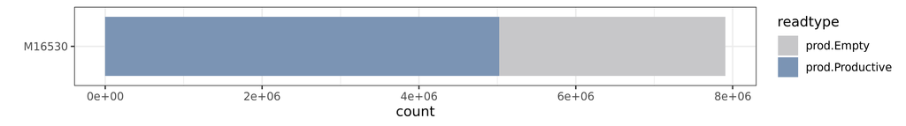

|  | short | magbead_loading | prod.Empty | prod.Productive | prod.Other | prod.Undefined | P0 | P1 | P2 |
| --- | --- | --- | --- | --- | --- | --- | --- | --- | --- |
| 1 | M16530 | False | 2883903 | 5024880 | 105888 | 10801 | 0.359988975278885 | 0.62724072276334 | 0.0132176819450344 |

# Internal Control Reads

Control reads are spiked in the run to assess sequencing quality and detect instrument/chemistry issues. These are aligned against a known genome to determine the error rate.

## Length

|  | short | count | count.rel | mean | mean.rel | median | median.rel |
| --- | --- | --- | --- | --- | --- | --- | --- |
| 1 | M16530 | 3584 | 0.000713250863702218 | 110173 | 0.930868340658757 | 78642 | 0.933314344714637 |

Ratio of control read count to total productive ZMWs, mean and median control read length and comparison to sample polymerase read lengths. Truncated control reads indicate sequencing problems, e.g. chemistry, but also overloading of the SMRTcell (compare productivity numbers). Control reads longer than your sample polymerase reads indicate sample problems.

## Quality

|  | short | mean | sd | median |
| --- | --- | --- | --- | --- |
| 1 | M16530 | 0.907398 | 0.018716 | 0.911569 |

Control read quality is another indicator for sequencing quality. Low quality (<.85) might also indicate overloading (compare productivity numbers).

# Polymerase Reads

Polymerase reads are reads within each ZMW (hole) that can consist of multiple passes of the fragment/insert.

|  | short | count | sum | mean | n50 | q05 | median | q95 | max |
| --- | --- | --- | --- | --- | --- | --- | --- | --- | --- |
| 1 | M16530 | 5006105 | 592497974073 | 118355.0833 | 242174 | 1465 | 84261 | 298314 | 510275 |

Number of polymerase reads (count) should correspond to P1 (productive ZMWs). `sum` shows the total number of basepairs; additionally various length statistics.

Number of total polymerase reads `count` and total bp `sum` vs polymerase reads with at least one full pass (`cx==3`). This is mostly interesting for consensus applications (Iso-Seq, Amplicons) and expected to be very low for long inserts.

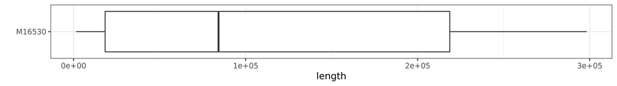

Polymerase read length statistics.

### Polymerase Reads with Full Passes

|  | short | count | sum | count.full | sum.full | ratio.count | ratio.sum |
| --- | --- | --- | --- | --- | --- | --- | --- |
| 1 | M16530 | 5006105 | 592497974073 | 3373134 | 556504399684 | 0.673804085211956 | 0.939251143524475 |

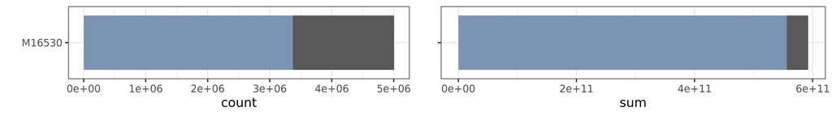

# Passes/Context

Each polymerase read can pass multiple times over the insert/fragment, producing multiple subreads per ZMW (hole). Only full passes over the insert (`cx==3`) are counted; pass count 0 means that no or only one of the adaptors (left or right) was read. Partial subreads can still be used for circular consensus, if there is at least one or more full passes (depending on the cutoff parameters you use).

| short | min | q05 | q25 | median | q75 | q95 | max |
| --- | --- | --- | --- | --- | --- | --- | --- |
| M16530 | 0 | 0 | 0 | 5 | 18 | 57 | 1090 |

Number of passes per ZMW. Shorter libraries will have more passes. Very long libraries will likely have only 1 pass (resp. maybe not even one full pass).

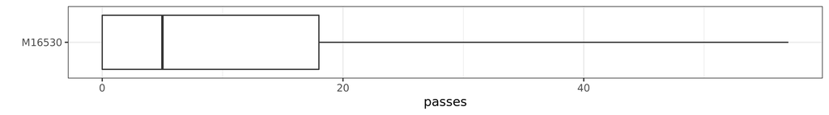

Boxplot for pass counts.

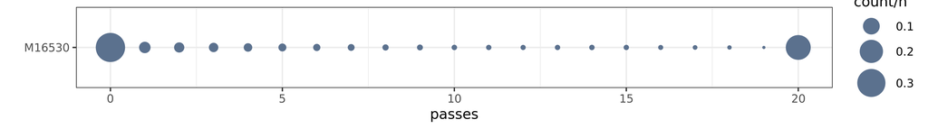

Histogram truncated at 20 passes

## Context Flag

The context flag shows for each subread whether no adapter (0), left (1) or right (2) or both (3) adapters could be read. Only CX flag 3 indicates a complete subread (end-to-end). Again, with very long libraries we do not expect many, if any, reads with CX flag 3.

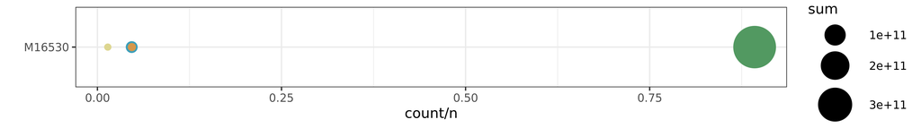

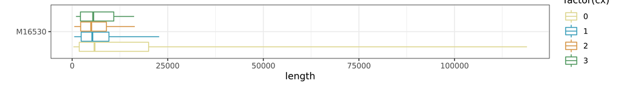

Length statistics within each CX flag bin.

# NoBloomCategorizer

We try to align a subsample of subreads (only one per ZMW) against some common genomes using minimap2.

| short | best_filter | rate_unique | rate_shared |
| --- | --- | --- | --- |
| M16530 | noMatch | 1 | 0 |

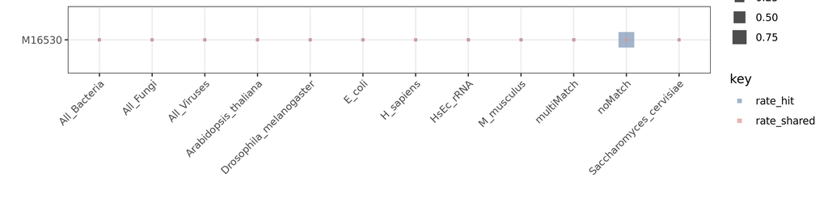

# Subreads

## Longest Subread

Longest subread shows only one subread per polymerase read/ZMW - the longest one (duh). This is the closest we get to “independent observations” (since all other subreads will have (part of) the same sequence).

|  | short | count | sum | mean | n50 | q25 | median | q75 |
| --- | --- | --- | --- | --- | --- | --- | --- | --- |
| 1 | M16530 | 5020691 | 85803130283 | 17089.9046 | 22292 | 6034 | 11471 | 16376 |

Number of subreads (count) should correspond to number of polymerase reads. `sum` is total basepairs; plus length statistics.

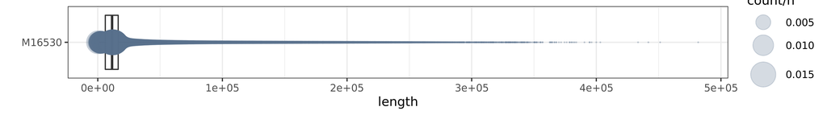

Boxplot for read lengths.

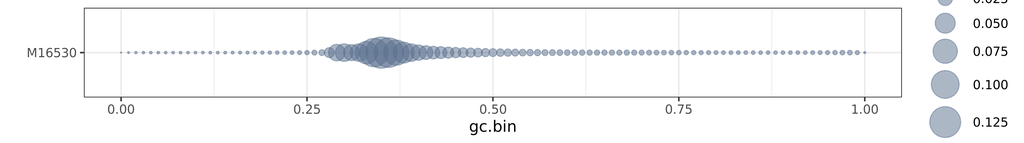

GC content calculated as ratio of GC/AT in each longest subread.

## All Subreads

|  | short | count | sum | mean | n50 | q25 | median | q75 |
| --- | --- | --- | --- | --- | --- | --- | --- | --- |
| 1 | M16530 | 81409876 | 589221153578 | 7237.711 | 11378 | 2182 | 5460 | 10796 |

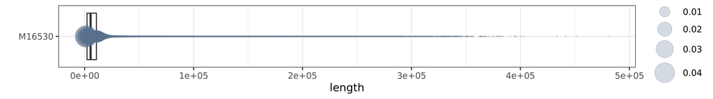